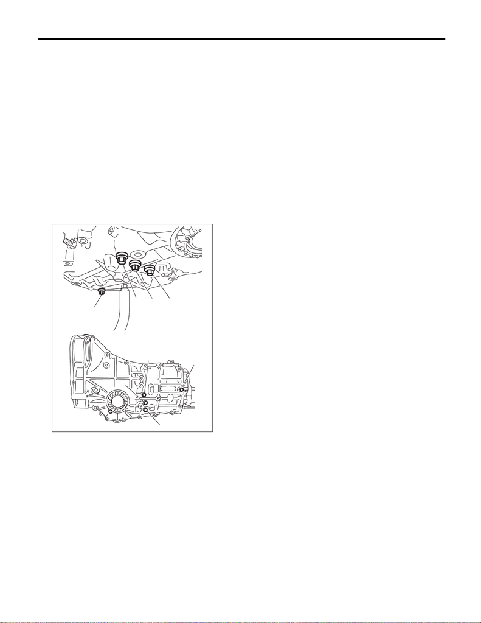

6MT(TY75)-135

Shifter Fork and Rod

MANUAL TRANSMISSION AND DIFFERENTIAL

20.Shifter Fork and Rod

A: REMOVAL

1) Remove the manual transmission assembly from the vehicle. <Ref. to 6MT(TY75)-25, REMOVAL, Manual

Transmission Assembly.>

2) Remove the back-up light switch and the neutral position switch. <Ref. to 6MT(TY75)-45, REMOVAL,

Switches and Harness.>

3) Remove the transfer case together with the extension case assembly. <Ref. to 6MT(TY75)-51, REMOV-

AL, Transfer Case and Extension Case Assembly.>

4) Remove the transmission case. <Ref. to 6MT(TY75)-79, REMOVAL, Transmission Case.>

5) Remove the drive pinion shaft assembly. <Ref. to 6MT(TY75)-92, REMOVAL, Drive Pinion Shaft Assem-

bly.>

6) Remove the main shaft assembly. <Ref. to 6MT(TY75)-83, REMOVAL, Main Shaft Assembly for Single-

Range.>

7) Remove the front differential assembly. <Ref. to 6MT(TY75)-111, REMOVAL, Front Differential Assem-

bly.>

8) Remove the reverse idler gear assembly. <Ref. to 6MT(TY75)-123, REMOVAL, Reverse Idler Gear.>

9) Remove the check ball plugs, check ball springs and check balls.

MT-02528

(A)

(B)

(D)

(C)

(A)

(B)

(D)

(C)

(A) 1st-2nd

(B) 3rd-4th

(C) 5th-6th

(D) Rev.

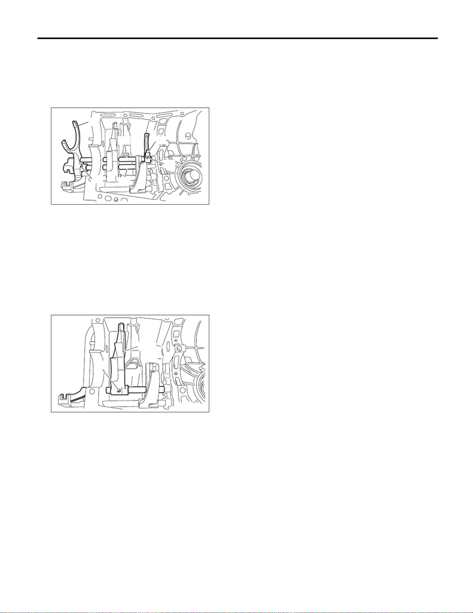

6MT(TY75)-136

Shifter Fork and Rod

MANUAL TRANSMISSION AND DIFFERENTIAL

10) Use the ST to push out the straight pin of 5th-6th shifter fork and reverse shifter fork, and remove the 5th-

6th shifter fork, reverse shifter fork, 5th-6th fork rod and reverse fork rod.

NOTE:

Tap out the reverse shifter fork straight pin, after setting the gear into reverse position. In the neutral position,

removing is impossible because the clearance between transmission case is narrow.

ST 398791700 SPRING PIN REMOVER 2

11) Drive out the straight pin by tapping with the ST, and remove the 3rd-4th shifter fork and 3rd-4th fork rod.

NOTE:

When removing the 3rd-4th fork rod, keep other fork rods in neutral.

ST 398791700 SPRING PIN REMOVER 2

MT-03080

(A)

(C)

(D)

(E)

(C)

(B)

(A) 5th-6th shifter fork

(B) Reverse shifter fork

(C) Straight pin

(D) 5th-6th fork rod

(E) Reverse fork rod

MT-03081

(A)

(B)

(C)

(A) 3rd-4th shifter fork

(B) 3rd-4th fork rod

(C) Straight pin

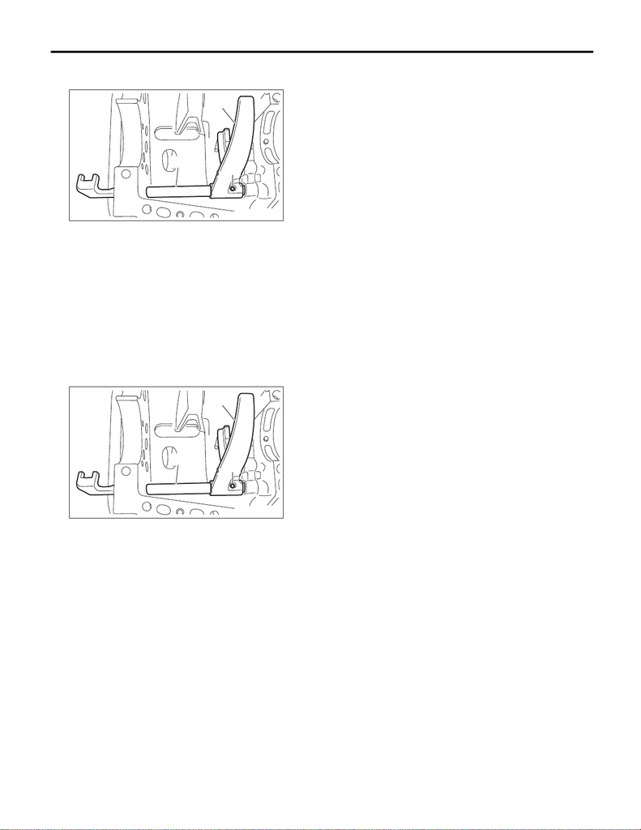

6MT(TY75)-137

Shifter Fork and Rod

MANUAL TRANSMISSION AND DIFFERENTIAL

12) Drive out the straight pin by tapping with the ST, and remove the 1st-2nd shifter fork and 1st-2nd fork rod.

ST 398791700 SPRING PIN REMOVER 2

B: INSTALLATION

1) Install the 1st-2nd fork rod to the 1st-2nd shifter fork through the hole on the rear of the transmission case.

2) Align the holes on the 1st-2nd fork rod and 1st-2nd shifter fork, and drive the straight pin into these holes

using the ST to fix.

NOTE:

Use a new straight pin.

ST 398791700 SPRING PIN REMOVER 2

3) Install the 3rd-4th fork rod to the 3rd-4th shifter fork through the hole on the rear of the transmission case.

MT-03082

(A)

(C)

(B)

(A) 1st-2nd shifter fork

(B) 1st-2nd fork rod

(C) Straight pin

MT-03082

(A)

(C)

(B)

(A) 1st-2nd shifter fork

(B) 1st-2nd fork rod

(C) Straight pin

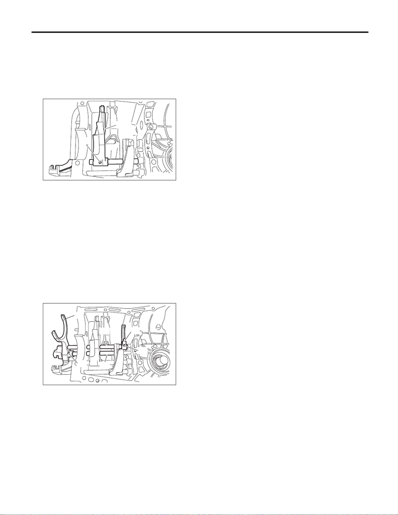

6MT(TY75)-138

Shifter Fork and Rod

MANUAL TRANSMISSION AND DIFFERENTIAL

4) Align the holes on the 3rd-4th fork rod and 3rd-4th shifter fork, and drive the straight pin into these holes

using the ST to fix.

NOTE:

• Use a new straight pin.

• Set other fork rods to neutral.

• Check that the positions of interlock plunger is correct.

ST 398791700 SPRING PIN REMOVER 2

5) Install the 5th-6th fork rod into 5th-6th shifter fork, then insert through the hole on the rear of transmission

case. Align the hole of the 5th-6th shifter fork with the hole on the transmission case, then insert the reverse

fork rod to install the reverse shifter fork.

6) Align the holes on the 5th-6th fork rod and 5th-6th shifter fork and the holes on the reverse fork rod and

reverse shifter fork, and drive the straight pin into these holes using the ST to fix.

NOTE:

• Use a new straight pin.

• Set other fork rods to neutral.

• Check that the positions of interlock plunger is correct.

ST 398791700 SPRING PIN REMOVER 2

MT-03081

(A)

(B)

(C)

(A) 3rd-4th shifter fork

(B) 3rd-4th fork rod

(C) Straight pin

MT-03080

(A)

(C)

(D)

(E)

(C)

(B)

(A) 5th-6th shifter fork

(B) Reverse shifter fork

(C) Straight pin

(D) 5th-6th fork rod

(E) Reverse fork rod

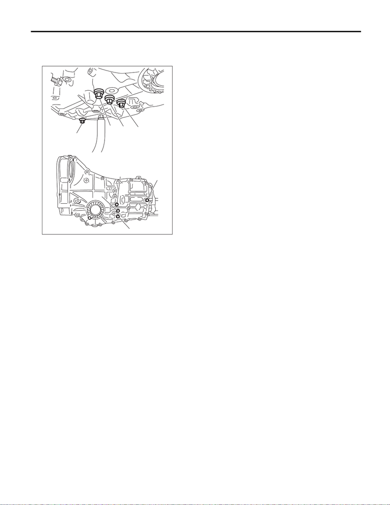

6MT(TY75)-139

Shifter Fork and Rod

MANUAL TRANSMISSION AND DIFFERENTIAL

7) Install the check ball plugs, check ball springs and check balls.

Tightening torque:

20 N·m (2.0 kgf-m, 14.8 ft-lb)

8) Install the reverse idler gear assembly. <Ref. to 6MT(TY75)-125, INSTALLATION, Reverse Idler Gear.>

9) Install the front differential assembly. <Ref. to 6MT(TY75)-112, INSTALLATION, Front Differential Assem-

bly.>

10) Install the main shaft assembly. <Ref. to 6MT(TY75)-83, INSTALLATION, Main Shaft Assembly for Sin-

gle-Range.>

11) Install the drive pinion shaft assembly. <Ref. to 6MT(TY75)-92, INSTALLATION, Drive Pinion Shaft As-

sembly.>

12) Install the transmission case. <Ref. to 6MT(TY75)-80, INSTALLATION, Transmission Case.>

13) Install the transfer case together with the extension case assembly. <Ref. to 6MT(TY75)-53, INSTALLA-

TION, Transfer Case and Extension Case Assembly.>

14) Install the back-up light switch and the neutral position switch. <Ref. to 6MT(TY75)-46, INSTALLATION,

Switches and Harness.>

15) Install the manual transmission assembly to the vehicle. <Ref. to 6MT(TY75)-30, INSTALLATION, Man-

ual Transmission Assembly.>

MT-02528

(A)

(B)

(D)

(C)

(A)

(B)

(D)

(C)

(A) 1st-2nd

(B) 3rd-4th

(C) 5th-6th

(D) Rev.

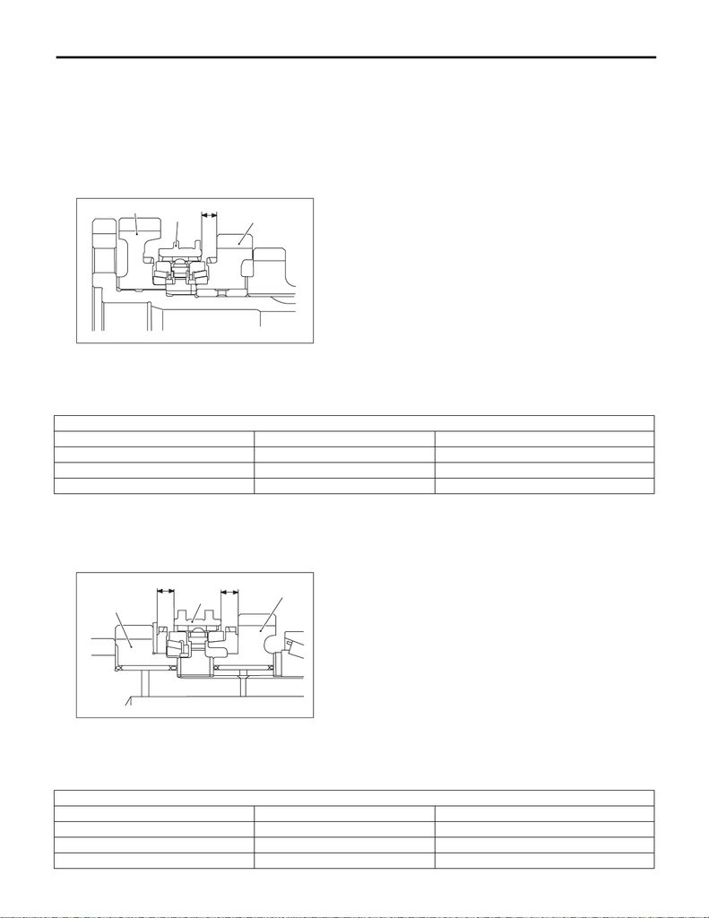

6MT(TY75)-140

Shifter Fork and Rod

MANUAL TRANSMISSION AND DIFFERENTIAL

C: INSPECTION

1) Check the fork and rod for damage. Replace if it is damaged.

2) Gearshift mechanism

Repair or replace the gearshift mechanism if excessively worn, bent or defective in any way.

3) Inspect the clearance between 2nd driven gear and coupling sleeve. If any clearance is not within speci-

fications, replace the shifter fork as required.

Clearance (a):

7.4 — 7.8 mm (0.291 — 0.307 in)

4) Inspect the clearance between the 3rd, 4th drive gear and the coupling sleeve. If any clearance is not with-

in specifications, replace the shifter fork as required.

Clearance (a), (b):

7.5 mm (0.295 in)

MT-02425

(B)

(C)

(A)

(a)

(A) 1st driven gear

(B) Coupling sleeve

(C) 2nd driven gear

1st-2nd shifter fork

Part No. Mark Remarks

32804AA120 1 Approaches 2nd gear by 0.2 mm (0.008 in).

32804AA130 No mark Standard

32804AA140 2 Approaches 1st gear by 0.2 mm (0.008 in).

MT-02426

(A)

(B)

(C)

(a)

(b)

(A) 3rd drive gear

(B) Coupling sleeve

(C) 4th drive gear

3rd-4th shifter fork

Part No. Mark Remarks

32810AA061 1 Approaches 4th gear by 0.2 mm (0.008 in).

32810AA071 No mark Standard

32810AA101 3 Approaches 3rd gear by 0.2 mm (0.008 in).

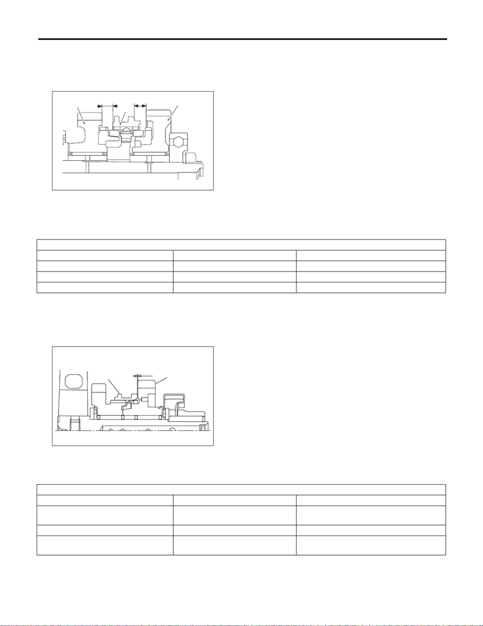

6MT(TY75)-141

Shifter Fork and Rod

MANUAL TRANSMISSION AND DIFFERENTIAL

5) Inspect the clearance between 5th, 6th drive gear and coupling sleeve. If any clearance is not within spec-

ifications, replace the shifter fork as required.

Clearance (a), (b):

7.5 mm (0.295 in)

6) Check the clearance between the reverse idler gear and reverse coupling sleeve. If any clearance is not

within specifications, replace the shifter fork as required.

Clearance (a):

0.50 mm (0.020 in) or less

MT-03187

(a)

(b)

(B)

(C)

(A)

(A) 5th drive gear

(B) 6th drive gear

(C) Coupling sleeve

5th-6th shifter fork

Part No. Mark Remarks

32940AA050 1 Approaches 5th gear by 0.2 mm (0.008 in).

32940AA060 No mark Standard

32940AA070 2 Approaches 6th gear by 0.2 mm (0.008 in).

MT-02434

(A)

(B)

(a)

(A) Reverse idler gear

(B) Reverse coupling sleeve

Reverse shifter fork

Part No. Mark Remarks

32941AA070 2

Approaches reverse idler gear by 0.3 mm

(0.012 in).

32941AA060 No mark Standard

32941AA050 1

Approaches reverse idler gear No. 2 by 0.3

mm (0.012 in).

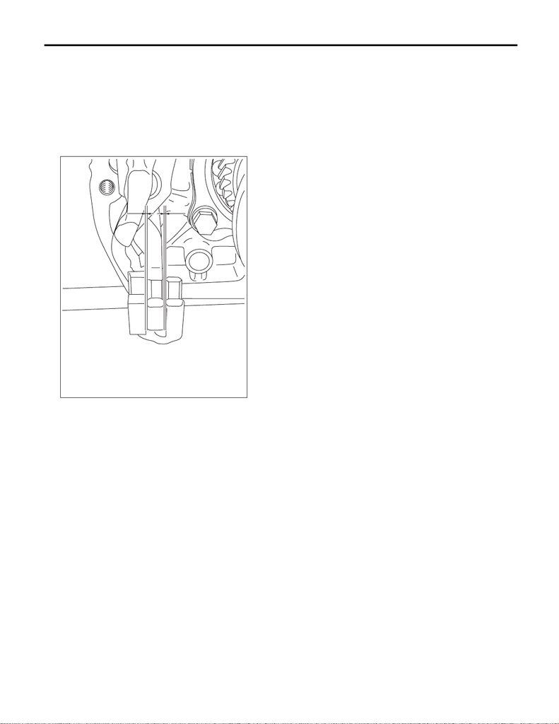

6MT(TY75)-142

Shifter Fork and Rod

MANUAL TRANSMISSION AND DIFFERENTIAL

7) Inspect the rod end clearances (A) and (B). If any clearance is not within specifications, replace the rod or

fork as required.

Clearance (A):

1st-2nd — 3rd-4th

0.1 — 0.9 mm (0.004 — 0.035 in)

Clearance (B):

3rd-4th — 5th-6th

0.2 — 1.0 mm (0.008 — 0.039 in)

MT-02529

(A)(B)